# Stochastic Volatility of Amazon Stock Price

2020/4/17

## Introduction

Stock market is usually hard to predict and full of volatility in the long time period. The risk, or the volatility is strongly asscociated with the expected returns. Many researches and papers have argued on this kind of relation. For example, Pindyck (1984) comments at early time that “much of the decline in stock prices during the 1970’s to increases in risk premiums arising from increases in volatility.” Therefore, we are interested in estimating the volaility and the other factors corresponding to it.

## Objective

We will explain the basic objective in the model starting with the introduction on expected return. The defintion of expected return is very financial: it is equal to the expected return on a stock market portfolio minus the interest rate given by the French’s paper (1987). Due to the time limit, we don’t have enough time to build a model to estimate an expected return as given formula:

$E(R_{mt}-R_{ft}|\hat\sigma_{mt})=\alpha+\beta\hat\sigma^p_{mt}$

where p=1,2…

## Data Analysis

### Descriptive Statistics

and take the logarithm as the scale and then take the difference to demean/detrend the data. In this dataset, the Price of the stock is the daily return.

```r
summary(Return)
```

```
##    Min. 1st Qu.  Median    Mean 3rd Qu.    Max.
##    1677    1781    1838    1853    1902    2170
```

```r
#Demeaned log Return
summary(R_log)
```

```
##       Min.    1st Qu.     Median       Mean    3rd Qu.       Max.
## -0.0825350 -0.0078165  0.0005142  0.0002900  0.0082846  0.0711957
```

Some descriptive statistics of both normal scale return and demeaned log return are shown at the above. The mean and median index for return is $1853 and $1838 across the whole time period. Also, the mean of log detrended Return is close to zero.

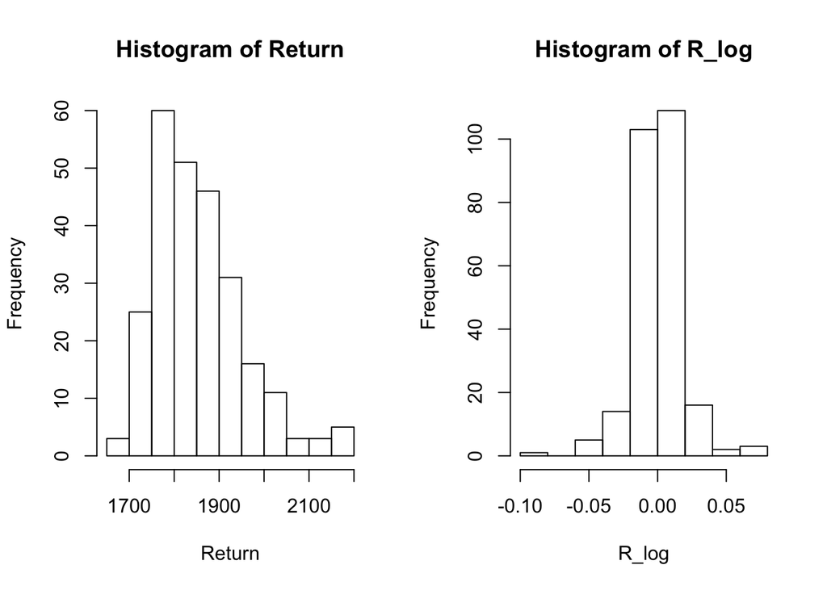

```r
par(mfcol=c(1,2))
hist(Return)
hist(R_log)
```

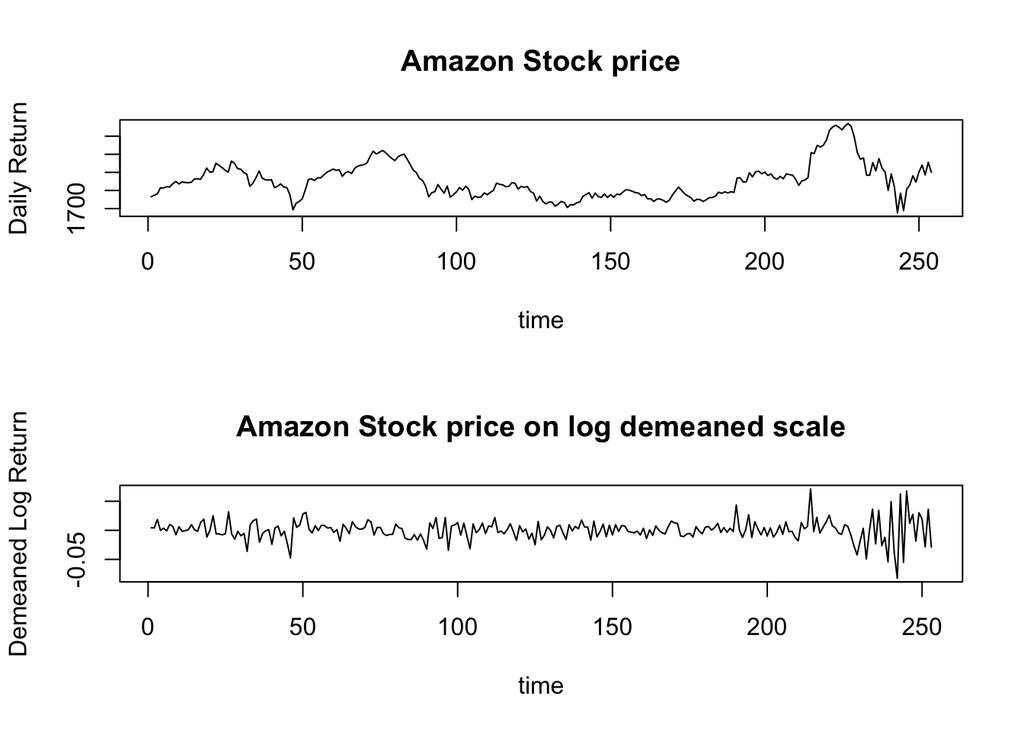

```r
par(mfcol=c(2,1))
plot(Return,xlab='time',ylab='Daily Return',type='l',main="Amazon Stock price")
plot(R_log,xlab='time',ylab='Demeaned Log Return',type='l',main="Amazon Stock price on log demeaned scale")
```

Here, we saw the histogram and time series plot on both units. Clearly, log-demeaned scale of return ($\textit{R_log}$ is better than the normal scale of return with the trend. ($\textit{R_log}$ will be used in the following analysis due to the better normality and more centered around 0.

### Construct the Benchmark Garch Model.

In the Financial Engineering, Garch model is very useful to estimate the volatility by given estimators or parameters. The part is following Note14 (Ionides, 2020), and construct a basic Garch(1,1) model as the benchmark, in order to compare with the later more complicated models. Here is the mathematical expression:

$Y_{n}=\epsilon_{n}\sqrt{V_{n}}$,

where $V_{n}=\alpha_0+\alpha_1Y^2_{n-1}+\beta_1V_{n-1}$

$\epsilon_{1:N}$ is the white noise.

```r
require(tseries)
fit.garch <- garch(R_log,grad = "numerical", trace = FALSE)
L.garch <- tseries:::logLik.garch(fit.garch)
L.garch
```

```
## 'log Lik.' 696.8425 (df=3)
```

From the result, the Garch(1,1) as the benchmark provides 697 as the max log-likelihood with df=3: 3 fitted parameters (Ionides, 2020).

### More complicated parameters on Financial Leverage and time-varing.

This conceptional information is cited from Note14 and also from a previous 2018 final prject “Investigate Financial Volatility of Google Stock” (2018). Besides the three parameters, we should also introduce a $\textit{leverage}$ to the correlation between index return on day t-1 and the increase volatility from day t-1 to t. (Ionides, 2020), then complete a more complicated Garch model:

$Y_{n}=exp({H_{n}/2}\epsilon_{n})$,

$H_{n}=\mu_{h}(1-\phi)+\phi H_{n-1}+\beta_{n-1}R_{n}exp(-H_{n-1}/2)+\omega_{n}$.

$G_{n}=G_{n-1}+\nu_{n}$

where $R_{n}=(exp{2G_{n}}-1)/(exp{2G_{n}}+1)$, $G_{n}$ is Gaussian random walk,

$\beta_{n}=Y_{n}\sigma_{\eta}\sqrt{1-\phi^2}$,${\epsilon_{n}}$ is an i.i.d N(0,1) sequence,

${v_{n}}$ is an i.i.d N(0,$\sigma_{\nu}^2$) sequence, ${\omega_{n}}$ is an i.i.d

N(0,$\sigma_{\omega}^2$) sequence, $\sigma_{\omega}^2=\sigma_{\eta}\sqrt{1-\phi^2}\sqrt{1-R_{n}^2}$

Those equations are cited in the Breto’s paper(2014), we will follow those and construct our POMP model then.

### Construct the new POMP/GARCH model

We will define the new Garch model with leverage and time varing parameters by following the codes in Note 14 step by step, and then set our parameters with testing values:

```r
params_test <- c( sigma_nu = 0.01, mu_h = -1.0, phi = expit(5), sigma_eta = 0.02, G_0 = 0, H_0=0 )
```

The particles and Nmifs associated with different run-levels are given as following:

```r
run_level <- 3
Amazon_Np <- switch(run_level, 100, 1e3, 2e3)
Amazon_Nmif <- switch(run_level, 10, 100, 200)
Amazon_Nreps_eval <- switch(run_level, 4, 10, 20)
Amazon_Nreps_local <- switch(run_level, 10, 20, 20)
Amazon_Nreps_global <- switch(run_level, 10, 20, 100)
```

Before start to fitting our model, we run a simple iterated filtering to check if our Monte Carlo algarithm goes well with small errors.

```r
stew(file=sprintf("Amazon1-%d.rda",run_level),{
   t.pf1 <- system.time(
     pf1 <-       foreach(i=1:Amazon_Nreps_eval,
                          .packages='pomp') %dopar% pfilter(sim1.filt,Np=Amazon_Np)) },seed=493536993,kind="L'Ecuyer")
(L.pf1 <- logmeanexp(sapply(pf1,logLik),se=TRUE))
```

```
##                          se
## -296.81923151    0.03590466
```

From this result, we see the log-likelihood is quite small, which doesn’t need us to worry a lot because we are checking if the particle filtering works with SMC algarithm, and the standard error turns out to be small so that we can build our model through this filtering confidently.

We have already defined the test values of parameters, we only need to assign the values of random work as the following:

```r
Amazon_rw.sd_rp <- 0.02
Amazon_rw.sd_ivp <- 0.1
Amazon_cooling.fraction.50 <- 0.5
Amazon_rw.sd <- rw.sd(
  sigma_nu = Amazon_rw.sd_rp,
  mu_h = Amazon_rw.sd_rp,
  phi = Amazon_rw.sd_rp,
  sigma_eta = Amazon_rw.sd_rp,
  G_0 = ivp(Amazon_rw.sd_ivp),
  H_0 = ivp(Amazon_rw.sd_ivp)
)
```

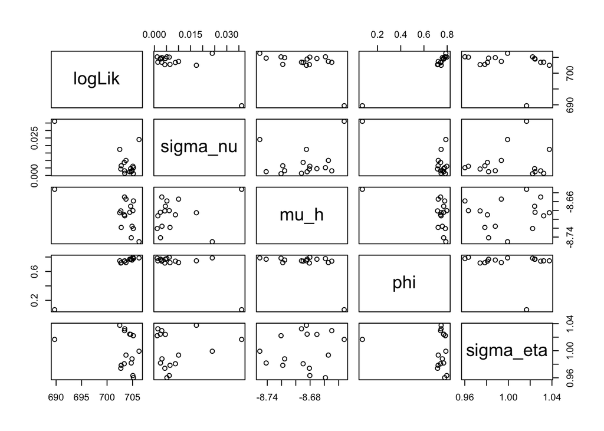

```r
pairs(~logLik+sigma_nu+mu_h+phi+sigma_eta, data=subset(r.if1,logLik>max(logLik)-25))
```

```r
summary(r.if1$logLik,digit=5)
```

```
##    Min. 1st Qu.  Median    Mean 3rd Qu.    Max.
##   661.4   699.3   703.4   694.9   704.8   706.3
```

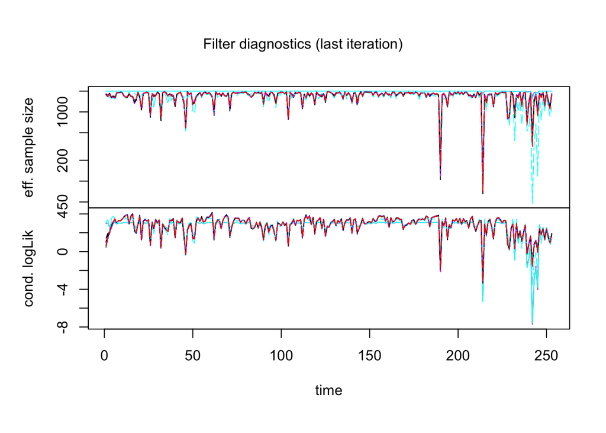

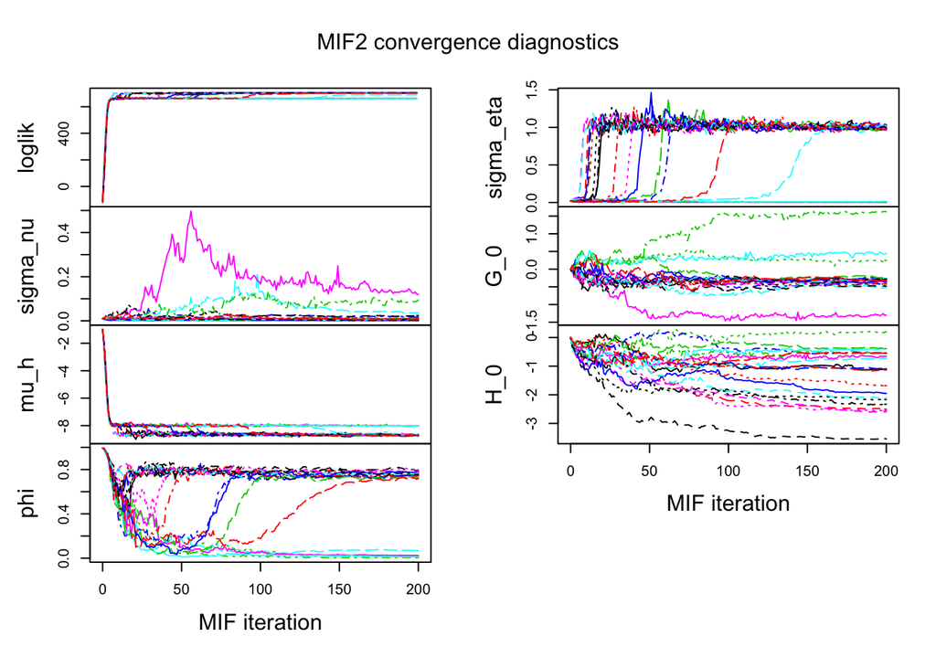

```r
plot(if1)
```

Here, from the result, we are able to improve our parameters from investigating the correlation matrix: we should mainly focus on the correlation between each parameter with log-likelihood. The $\sigma_{v}$ shows most of values with high log-lik concentrate around 0.000 and 0.015. Also, the $\phi$ indicates a positive correlation with log-lik so we set the range to be from 0.7 to 1.0. However, $\mu_{h}$ and $\sigma_{\eta}$ both give us no clear relation to log-lik, it seems that we ought to take as large as intervals we can to set the values.

Now, the maximum log-likelihood is 706, an improvment compares to the previous inference: 697.

We will not go further into the interpretation on MIF2 convergence until we have the final fitted model.

The refined parameters are given below and we start to fit the model.

```r
Amazon_box <- rbind( sigma_nu=c(0.001,0.015), mu_h =c(-8.60, -8.80), phi = c(0.7,0.9), sigma_eta = c(0.90,1.2), G_0 = c(-2,2), H_0 = c(-1,1) )
```

```r
summary(r.box$logLik,digits=5)
```

```
##    Min. 1st Qu.  Median    Mean 3rd Qu.    Max.
##   676.0   685.0   702.6   696.4   704.3   706.8
```

After the re-estimation on the range of parameter values, we obtain the a little bit increase in maximum log-likelihood on our Garch model, which increases from 706.3 to 706.8.

```r
r.if1[which.max(r.if1$logLik),]
```

```
##            logLik  logLik_se   sigma_nu      mu_h       phi sigma_eta
## result.7 706.2785 0.05082273 0.02398174 -8.750484 0.7883372 0.9992628
##                 G_0      H_0
## result.7 -0.4825398 -3.53976
```

```r
r.box[which.max(r.box$logLik),]
```

```
##             logLik logLik_se    sigma_nu      mu_h       phi sigma_eta
## result.72 706.8434 0.0430501 0.003684491 -8.611061 0.8167036  1.024579
##                  G_0       H_0
## result.72 -0.3668632 -3.741932
```

We also compared the standard errors of log-likelihood and see a smaller deviation in the new estimation. $\sigma_{\nu}$ decreased from 0.024 to 0.0037. Other parameters change a little expect $\sigma_{\eta}$.

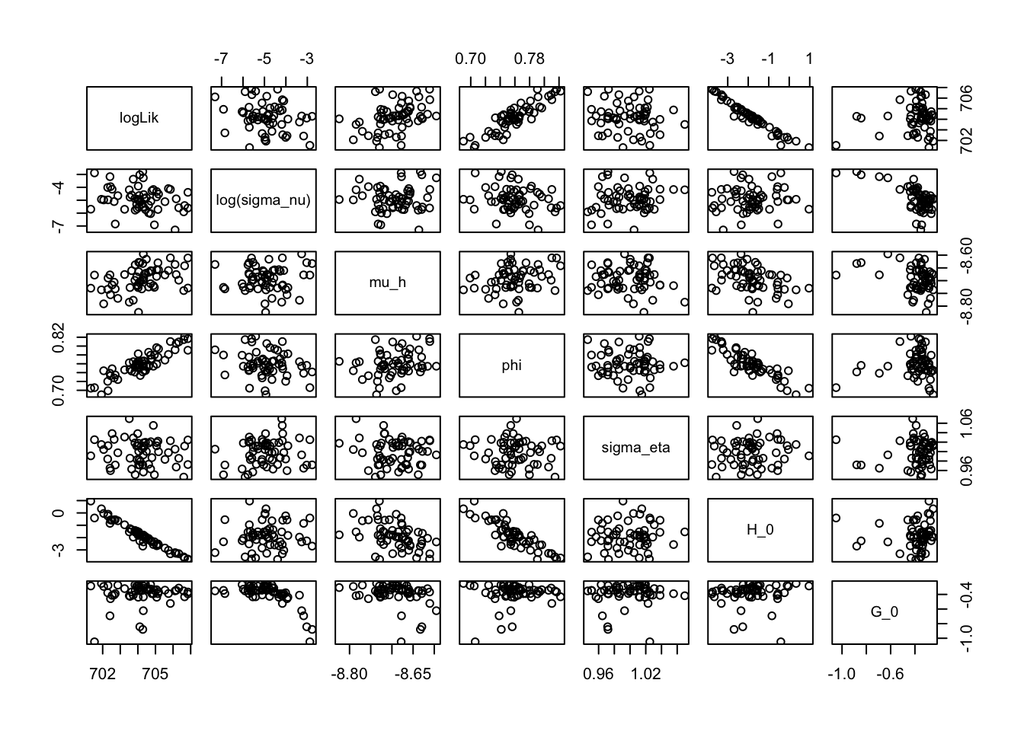

```r
pairs(~logLik+log(sigma_nu)+mu_h+phi+sigma_eta+H_0+G_0, data=subset(r.box,logLik>max(logLik)-10))
```

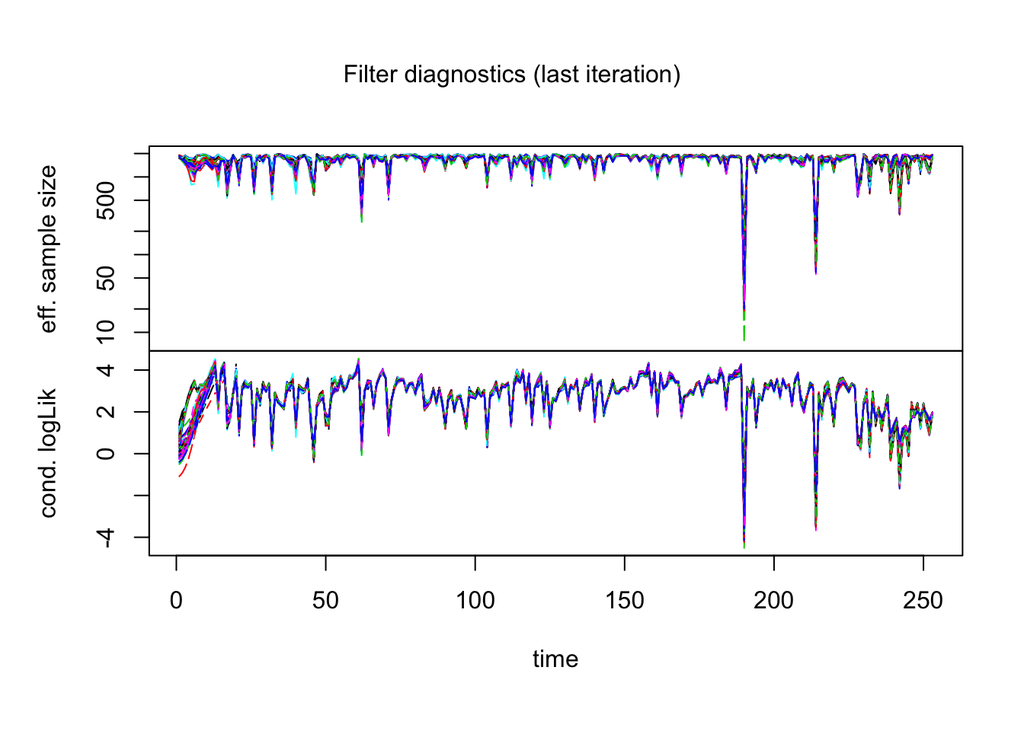

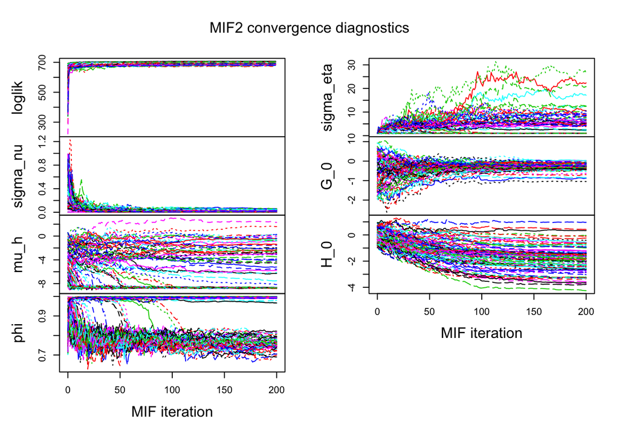

```r
plot(if.box)
```

The final step of our Garch leverage and time varing model is to check the correlation scatterplot matrix and likelihood surface.

From this scatterplot matrix, we could see a weak evidence that $log(\sigma_{\nu})$ is negatively correlated with better inference. It means that the closer $\sigma_{\nu}$ to the zero, the higher log-likelikhood it will be. Then, $\mu_{h}$ shows a weakly positive correlation to the likelihood. While $\phi$ gives a strong positive correlation and $H_0$ is negatively correlated to log-lik in also strong evidence. However, the rest of two parameters: $\sigma_{\eta}$ and $G_0$ are lack of significance in the graph.

From the Convergence diagnostic plot, we see the log-likelihood converges very quickly at the front several iterations. In addition,$\sigma_{\nu}$ and $G_0$ converge well after 50 times iterations. $\sigma_{\nu}$ stays in the interval between 0 and 0.2, and $G_0$ stays around -1 and 0.